# Task 9 - Critical Evaluation of Time Series Analysis

Retail Product Demand Analysis at Fragceylon

IT3081 Statistical Modelling

21 September 2026

# 1 Task 9 Overview

Task 9 critically evaluates whether **time series analysis** is appropriate for the Fragceylon retail product demand dataset.

The assignment requires discussion of:

- trend;
- seasonality;
- forecasting;
- ARIMA;
- organizational applications and benefits.

A full production time-series model is **not required**.

Therefore, the objective is not to force ARIMA or SARIMA onto a short historical series. Instead, this section evaluates whether the available history is sufficiently long, stable and comparable for dependable time-series modelling.

The evaluation uses:

1. historical-span analysis;
2. structural-regime assessment;
3. monthly demand aggregation;
4. calendar-coverage checks;
5. exploratory trend analysis;
6. exploratory autocorrelation analysis;
7. seasonality-readiness assessment;
8. weekly versus monthly aggregation comparison;
9. product-level time-series readiness;
10. ARIMA/SARIMA applicability discussion.

# 2 1. Load the Regular-Order Dataset

```r
regular_orders = read_excel(
  "04_Cleaned_Data/Fragceylon_Regular_Orders.xlsx"
)

regular_orders$Date = as.Date(
  regular_orders$Date
)

dim(
  regular_orders
)
```

```
## [1] 3116   22
```

```r
range(
  regular_orders$Date
)
```

```
## [1] "2024-10-18" "2026-06-30"
```

The Regular Order dataset contains:

- **3,116 observations**
- **4 perfume products**
- sales history from **18 October 2024 to 30 June 2026**

# 3 2. Historical Span

```r
history_summary = read.csv(
  "08_Model_Results/R/Task9_Historical_Span_Summary.csv",
  stringsAsFactors = FALSE
)

kable(
  history_summary,
  caption = "Historical Span Summary"
)
```

Historical Span Summary

| Measure | Value |
| --- | --- |
| Overall start date | 2024-10-18 |
| Overall end date | 2026-06-30 |
| Overall calendar days | 621 |
| Overall approximate years | 1.7002 |
| Pre-April-2025 rows | 1102 |
| Current-regime rows | 2014 |
| Current-regime start date | 2025-04-01 |
| Current-regime end date | 2026-06-30 |
| Current-regime calendar days | 456 |
| Current-regime approximate years | 1.2485 |

The full Regular Order history contains approximately:

```
621 calendar days
≈ 1.70 years
```

However, the full historical span cannot automatically be treated as one stable time series because the business structure changes sharply on **1 April 2025**.

# 4 3. Structural Regime Change

```r
regime_structure = read.csv(
  "08_Model_Results/R/Task9_Regime_Channel_Structure.csv",
  row.names = 1,
  check.names = FALSE
)

kable(
  regime_structure,
  caption = "Channel Structure Before and After 1 April 2025"
)
```

Channel Structure Before and After 1 April 2025

|  | Main Dealer | Shop | Small Dealer |
| --- | --- | --- | --- |
| 2025-04-01 onward | 2014 | 0 | 0 |
| Before 2025-04-01 | 0 | 751 | 351 |

The channel structure changes completely:

```
Before 2025-04-01
Main Dealer       0
Shop            751
Small Dealer    351

2025-04-01 onward
Main Dealer    2014
Shop              0
Small Dealer      0
```

This is a major structural break in the business process.

A time-series model fitted across the whole period could confuse:

- changes in sales channel;
- changes in order size;
- changes in customer structure;

with a genuine trend or seasonal pattern.

Therefore, the post-April-2025 period is treated as the more comparable current regime.

# 5 4. Monthly Demand Series

```r
monthly_demand = read.csv(
  "08_Model_Results/R/Task9_Monthly_Total_Demand.csv",
  stringsAsFactors = FALSE
)

monthly_demand$Month_Start = as.Date(
  monthly_demand$Month_Start
)

kable(
  monthly_demand,
  caption = "Monthly Regular-Order Demand"
)
```

Monthly Regular-Order Demand

| Month_Start | Quantity | Order_Lines | Period |
| --- | --- | --- | --- |
| 2024-10-01 | 1556 | 27 | Pre-April-2025 structure |
| 2024-11-01 | 12044 | 148 | Pre-April-2025 structure |
| 2024-12-01 | 28450 | 377 | Pre-April-2025 structure |
| 2025-01-01 | 27557 | 364 | Pre-April-2025 structure |
| 2025-02-01 | 3717 | 45 | Pre-April-2025 structure |
| 2025-03-01 | 9891 | 141 | Pre-April-2025 structure |
| 2025-04-01 | 103212 | 335 | Current Main Dealer regime |
| 2025-05-01 | 13588 | 37 | Current Main Dealer regime |
| 2025-06-01 | 7119 | 22 | Current Main Dealer regime |
| 2025-07-01 | 2983 | 9 | Current Main Dealer regime |
| 2025-08-01 | 7002 | 23 | Current Main Dealer regime |
| 2025-09-01 | 11286 | 38 | Current Main Dealer regime |
| 2025-10-01 | 12086 | 44 | Current Main Dealer regime |
| 2025-11-01 | 49323 | 150 | Current Main Dealer regime |
| 2025-12-01 | 115818 | 395 | Current Main Dealer regime |
| 2026-01-01 | 106387 | 340 | Current Main Dealer regime |
| 2026-02-01 | 17899 | 58 | Current Main Dealer regime |
| 2026-03-01 | 43471 | 148 | Current Main Dealer regime |
| 2026-04-01 | 107546 | 332 | Current Main Dealer regime |
| 2026-05-01 | 12241 | 41 | Current Main Dealer regime |
| 2026-06-01 | 12634 | 42 | Current Main Dealer regime |

The full dataset contains **21 monthly observations**.

Monthly demand varies substantially across the period.

This variability may reflect:

- actual demand changes;
- changes in order timing;
- dealer purchasing patterns;
- the structural channel change;
- possible seasonality;
- other business factors not recorded in the current dataset.

Therefore, visual fluctuations should not automatically be interpreted as recurring seasonal effects.

# 6 5. Monthly Demand and Regime Change

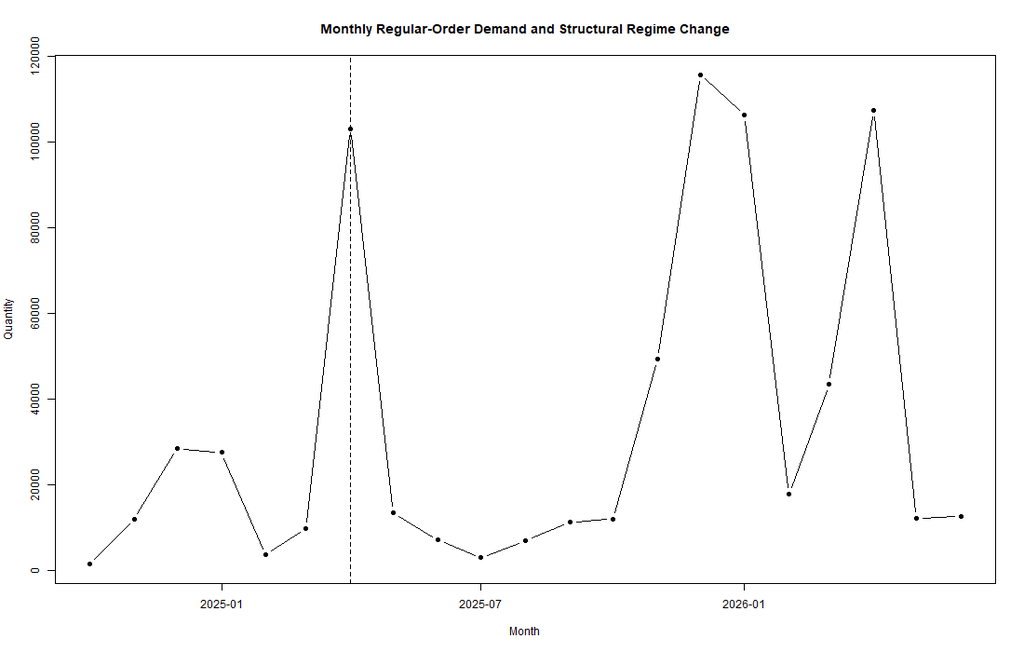

The vertical reference line marks the start of the Main Dealer regime.

The substantial difference between the pre-April-2025 period and the later period reinforces the need to avoid treating the entire history as a homogeneous time series.

# 7 6. Calendar Coverage

```r
calendar_coverage = read.csv(
  "08_Model_Results/R/Task9_Monthly_Calendar_Coverage.csv",
  stringsAsFactors = FALSE
)

kable(
  calendar_coverage,
  digits = 2,
  caption = "Monthly Calendar Coverage"
)
```

Monthly Calendar Coverage

| Month_Start | Calendar_Days | Observed_Days | Coverage_Percent | Full_Calendar_Month |
| --- | --- | --- | --- | --- |
| 2024-10-01 | 31 | 14 | 45.16 | FALSE |
| 2024-11-01 | 30 | 30 | 100.00 | TRUE |
| 2024-12-01 | 31 | 31 | 100.00 | TRUE |
| 2025-01-01 | 31 | 31 | 100.00 | TRUE |
| 2025-02-01 | 28 | 28 | 100.00 | TRUE |
| 2025-03-01 | 31 | 31 | 100.00 | TRUE |
| 2025-04-01 | 30 | 30 | 100.00 | TRUE |
| 2025-05-01 | 31 | 31 | 100.00 | TRUE |
| 2025-06-01 | 30 | 30 | 100.00 | TRUE |
| 2025-07-01 | 31 | 31 | 100.00 | TRUE |
| 2025-08-01 | 31 | 31 | 100.00 | TRUE |
| 2025-09-01 | 30 | 30 | 100.00 | TRUE |
| 2025-10-01 | 31 | 31 | 100.00 | TRUE |
| 2025-11-01 | 30 | 30 | 100.00 | TRUE |
| 2025-12-01 | 31 | 31 | 100.00 | TRUE |
| 2026-01-01 | 31 | 31 | 100.00 | TRUE |
| 2026-02-01 | 28 | 28 | 100.00 | TRUE |
| 2026-03-01 | 31 | 31 | 100.00 | TRUE |
| 2026-04-01 | 30 | 30 | 100.00 | TRUE |
| 2026-05-01 | 31 | 31 | 100.00 | TRUE |
| 2026-06-01 | 30 | 30 | 100.00 | TRUE |

October 2024 is only a partial month:

```
Observed days: 14 of 31
Coverage: approximately 45.16%
```

All later months are complete calendar months.

This matters because a partial month should not be compared directly with a complete month when evaluating trend or seasonality.

# 8 7. Current Stable Regime

The current Main Dealer regime contains:

```
April 2025 to June 2026
15 monthly observations
```

This is approximately:

```
1.25 years
```

of comparable monthly history.

That is the most important limitation for time-series modelling in this project.

# 9 8. Seasonality Requires Repeated Comparable Cycles

Annual seasonality means that similar effects repeat at roughly the same time each year.

For monthly data, reliable seasonal analysis requires repeated observations of the same calendar months across comparable years.

```r
month_replication = read.csv(
  "08_Model_Results/R/Task9_Current_Regime_Month_Replication.csv",
  stringsAsFactors = FALSE
)

kable(
  month_replication,
  caption = "Current-Regime Month-of-Year Replication"
)
```

Current-Regime Month-of-Year Replication

| Month | Number_of_Current_Regime_Observations |
| --- | --- |
| January | 1 |
| February | 1 |
| March | 1 |
| April | 2 |
| May | 2 |
| June | 2 |
| July | 1 |
| August | 1 |
| September | 1 |
| October | 1 |
| November | 1 |
| December | 1 |

Only:

- April;
- May;
- June;

appear twice in the current regime.

Every other calendar month appears only once.

Therefore, the current data do not provide repeated evidence for most annual months.

# 10 9. Direct 12-Month Comparisons

```r
lag12 = read.csv(
  "08_Model_Results/R/Task9_Current_Regime_Lag12_Comparisons.csv",
  stringsAsFactors = FALSE
)

kable(
  lag12,
  caption = "Direct Same-Month Comparisons 12 Months Apart"
)
```

Direct Same-Month Comparisons 12 Months Apart

| Earlier_Month | Later_Month | Earlier_Quantity | Later_Quantity | Difference |
| --- | --- | --- | --- | --- |
| 2025-04-01 | 2026-04-01 | 103212 | 107546 | 4334 |
| 2025-05-01 | 2026-05-01 | 13588 | 12241 | -1347 |
| 2025-06-01 | 2026-06-01 | 7119 | 12634 | 5515 |

Only three direct annual comparisons are available:

```
April 2025 → April 2026   +4,334
May 2025   → May 2026     -1,347
June 2025  → June 2026    +5,515
```

These differences are not consistent enough, and the sample is too small, to establish a dependable yearly seasonal pattern.

Therefore:

> **Annual seasonality is not established by the current Fragceylon data.**

# 11 10. Exploratory Trend Analysis

A simple linear trend was fitted to the 15 current-regime monthly totals.

This is a descriptive diagnostic only.

It is not a production forecasting model.

```r
trend_assessment = read.csv(
  "08_Model_Results/R/Task9_Current_Regime_Trend_Assessment.csv",
  stringsAsFactors = FALSE
)

kable(
  trend_assessment,
  digits = 4,
  caption = "Exploratory Current-Regime Trend Assessment"
)
```

Exploratory Current-Regime Trend Assessment

| Metric | Value |
| --- | --- |
| Monthly trend coefficient | 1244.9429 |
| Trend standard error | 2682.5784 |
| Trend t statistic | 0.4641 |
| Trend p value | 0.6503 |
| Trend 95% CI lower | -4550.4153 |
| Trend 95% CI upper | 7040.3011 |
| Model R-squared | 0.0163 |
| Adjusted R-squared | -0.0594 |
| Current-regime monthly observations | 15.0000 |

The estimated monthly trend is approximately:

```
+1,244.94 units per month
```

However:

```
p-value = 0.6503
95% CI = -4,550.42 to 7,040.30
R-squared = 0.0163
```

The interval includes zero by a wide margin and the model explains very little of the monthly variation.

Therefore, there is **no convincing evidence of a linear monthly trend** in the current stable regime.

# 12 11. Current-Regime Monthly Trend Chart

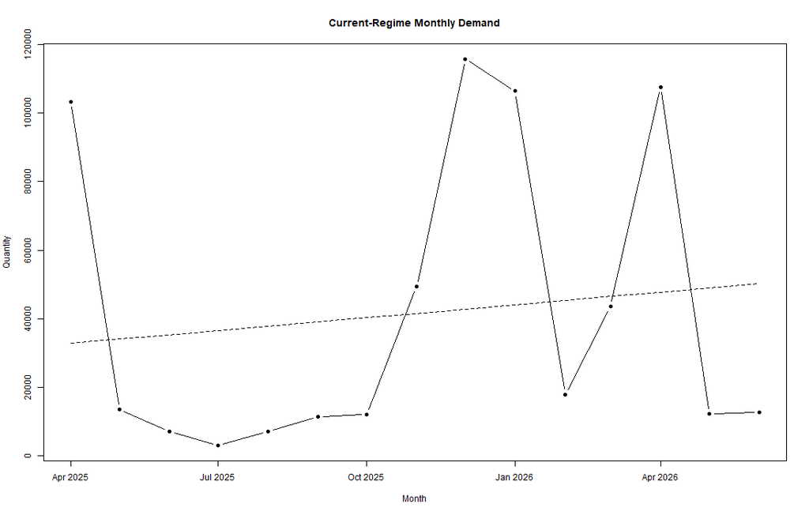

The fitted trend line is weak relative to the large month-to-month fluctuations.

A positive fitted slope should therefore not be interpreted as proven demand growth.

# 13 12. Autocorrelation

Time-series models such as ARIMA use temporal dependence in past observations.

An exploratory autocorrelation function was therefore calculated.

```r
acf_table = read.csv(
  "08_Model_Results/R/Task9_Current_Regime_ACF.csv",
  stringsAsFactors = FALSE
)

kable(
  acf_table,
  digits = 4,
  caption = "Exploratory ACF of Current-Regime Monthly Demand"
)
```

Exploratory ACF of Current-Regime Monthly Demand

| Lag | Autocorrelation |
| --- | --- |
| 0 | 1.0000 |
| 1 | 0.2426 |
| 2 | -0.1782 |
| 3 | 0.0456 |
| 4 | -0.0263 |
| 5 | -0.3489 |
| 6 | -0.4000 |
| 7 | -0.1631 |
| 8 | 0.1114 |
| 9 | 0.1477 |
| 10 | -0.0623 |
| 11 | 0.0149 |
| 12 | 0.2210 |

Selected values include approximately:

```
Lag 1   =  0.243
Lag 5   = -0.349
Lag 6   = -0.400
Lag 12  =  0.221
```

These values should be interpreted very cautiously because the stable monthly series contains only 15 observations.

A lag-12 autocorrelation based on such a short series is not sufficient evidence of annual seasonality.

# 14 13. Exploratory ACF Plot

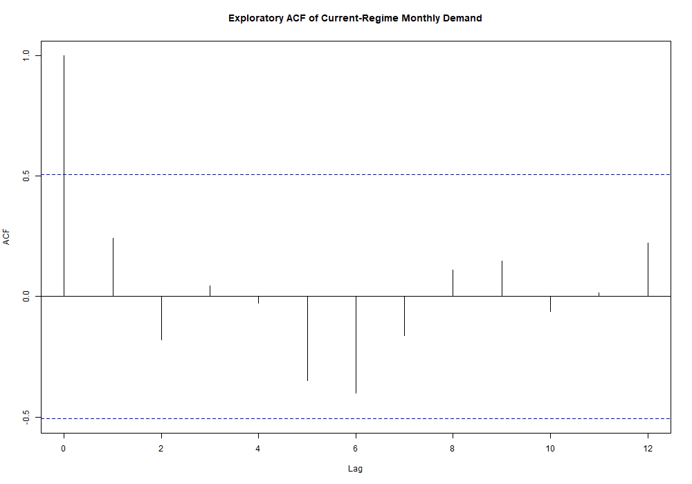

The ACF is included as an exploratory diagnostic only.

It should **not** be used to select a production ARIMA order from the current dataset.

# 15 14. Why ARIMA Is Not Fitted as a Final Model

ARIMA models can be useful when a series contains enough information to estimate:

- autoregressive structure;
- differencing requirements;
- moving-average structure;
- residual behaviour.

The current monthly series has only **15 comparable observations**.

This is too little history to confidently distinguish genuine temporal structure from random monthly variation.

Therefore, fitting an ARIMA model merely because ARIMA appears in the assignment would create a false sense of precision.

# 16 15. Why SARIMA Is Even More Difficult to Justify

SARIMA extends ARIMA with seasonal components.

For monthly retail data, annual seasonality would normally use a seasonal period of 12.

The current comparable history provides only:

```
15 months
≈ 1.25 annual cycles
```

This is not enough repeated seasonal information for dependable estimation of annual seasonal parameters.

A SARIMA model may become useful later, but it is not well supported by the current evidence.

# 17 16. Product-Level Demand

Time-series forecasting may eventually be more useful at individual perfume level because different products may show different demand patterns.

```r
product_coverage = read.csv(
  "08_Model_Results/R/Task9_Product_Monthly_Coverage.csv",
  stringsAsFactors = FALSE
)

kable(
  product_coverage,
  caption = "Product-Level Current-Regime Monthly Coverage"
)
```

Product-Level Current-Regime Monthly Coverage

| Product.Name | Observed_Current_Regime_Months |
| --- | --- |
| Dark Matrix | 15 |
| Kennedy | 15 |
| Mesmerose | 15 |
| Secret Ambrosia | 15 |

Each perfume has only **15 current-regime monthly observations**.

Therefore, splitting the total series by perfume improves business relevance but reduces the effective amount of information available for each model.

# 18 17. Monthly Demand by Perfume

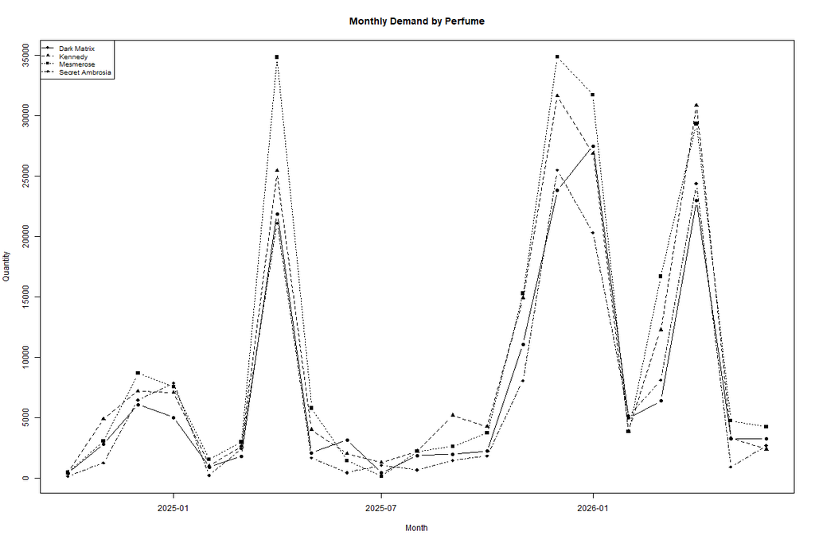

The four product series show substantial variation.

This supports future product-level modelling, but the current time span remains too short to confidently separate:

- product trend;
- annual seasonality;
- irregular dealer ordering;
- one-off demand spikes.

# 19 18. Weekly Versus Monthly Aggregation

A possible response to the short monthly series is to aggregate sales weekly.

This produces more observations.

```r
aggregation_comparison = read.csv(
  "08_Model_Results/R/Task9_Aggregation_Frequency_Comparison.csv",
  stringsAsFactors = FALSE
)

kable(
  aggregation_comparison,
  digits = 4,
  caption = "Monthly and Weekly Aggregation Comparison"
)
```

Monthly and Weekly Aggregation Comparison

| Aggregation | Observations | Approx_Seasonal_Period | Approx_Number_of_Seasonal_Cycles |
| --- | --- | --- | --- |
| Monthly - full history | 21 | 12 | 1.7500 |
| Monthly - current regime | 15 | 12 | 1.2500 |
| Weekly - full history | 90 | 52 | 1.7308 |
| Weekly - current regime | 65 | 52 | 1.2500 |

The comparison is:

| Aggregation | Observations | Approximate seasonal cycles |
| --- | --- | --- |
| Monthly - full history | 21 | 1.75 |
| Monthly - current regime | 15 | 1.25 |
| Weekly - full history | 90 | 1.73 |
| Weekly - current regime | 65 | 1.25 |

Weekly aggregation provides more individual observations.

However, it does **not create additional years of history**.

A 52-week annual cycle still contains only about 1.25 comparable cycles in the current regime.

Therefore, weekly data do not solve the central seasonality limitation.

# 20 19. Advantages of Monthly Aggregation

Monthly aggregation has several benefits:

- easier communication to management;
- alignment with purchasing and inventory planning;
- lower short-term noise than daily or weekly sales;
- clear comparison with month-based business reporting.

Its main current limitation is the very small number of observations.

# 21 20. Advantages and Limitations of Weekly Aggregation

Weekly aggregation provides more observations and may support short-horizon operational forecasting.

However, it may also introduce:

- greater short-term volatility;
- irregular ordering effects;
- week-boundary effects;
- stronger sensitivity to delivery schedules;
- incomplete weekly periods.

For annual seasonality, multiple years are still required.

# 22 21. Time-Series Applicability Assessment

```r
time_series_applicability = read.csv(
  "08_Model_Results/R/Task9_Time_Series_Applicability.csv",
  stringsAsFactors = FALSE
)

kable(
  time_series_applicability,
  caption = "Time-Series Method Applicability Assessment"
)
```

Time-Series Method Applicability Assessment

| Area | Current_Assessment | Key_Limitation |
| --- | --- | --- |
| Trend analysis | Possible descriptively, but trend estimates should be treated cautiously because the current stable regime contains only 15 monthly observations. | Short stable time span and structural business change. |
| Seasonal analysis | Weakly supported for annual seasonality because the current stable regime covers only about 1.25 years and has very few repeated calendar months. | Insufficient repeated annual cycles. |
| Forecasting | Short-horizon exploratory forecasting may be possible, but dependable operational forecasting requires a longer stable history. | Forecast uncertainty would be high and structural change may not persist. |
| ARIMA | Conceptually applicable to autocorrelated demand after sufficient stable history is collected and stationarity is assessed. | Model identification and diagnostics are unreliable with very short series. |
| SARIMA | Potentially useful if clear annual seasonality emerges, but current history is too short for dependable seasonal ARIMA estimation. | Seasonal parameters need repeated comparable seasonal cycles. |
| Product-level forecasting | Potentially valuable because each perfume may have different demand dynamics, but each product still has limited stable historical coverage. | Smaller effective sample within each individual product series. |
| Weekly aggregation | Provides more observations, but order timing may be noisy and a 52-week seasonal cycle still requires multiple comparable years. | Higher short-term variability and irregular ordering behaviour. |
| Monthly aggregation | Easy to communicate and useful for management planning, but only 15 stable-regime monthly observations are currently available. | Very small sample size for time-series model estimation. |

The current evidence supports the following interpretation:

- trend analysis is possible descriptively;
- annual seasonality is weakly supported;
- short-horizon exploratory forecasting may be possible;
- ARIMA is a future option after more stable history is collected;
- SARIMA should wait until repeated annual cycles exist;
- product-level forecasting is potentially useful but currently data-limited.

# 23 22. Future ARIMA Framework

Once a longer stable history has been collected, a monthly series could be created as:

```r
monthly_ts = ts(
  future_monthly_data$Quantity,
  frequency = 12,
  start = c(2027, 1)
)
```

A non-seasonal ARIMA model could then be investigated using:

```r
fit_arima = arima(
  monthly_ts,
  order = c(p, d, q)
)
```

The values of `p`, `d`, and `q` should be selected using appropriate diagnostics and forecast validation rather than guessed in advance.

# 24 23. Future SARIMA Framework

If repeated annual seasonality becomes evident, a seasonal model could be considered:

```r
fit_sarima = arima(
  monthly_ts,
  order = c(p, d, q),
  seasonal = list(
    order = c(P, D, Q),
    period = 12
  )
)
```

A SARIMA model should only be used if the future dataset provides enough repeated seasonal cycles to estimate and validate the seasonal structure.

# 25 24. Residual Diagnostics for Future Models

Any future ARIMA/SARIMA model should be checked using residual diagnostics.

For example:

```r
acf(
  residuals(
    fit_arima
  )
)

Box.test(
  residuals(
    fit_arima
  ),
  lag = appropriate_lag,
  type = "Ljung-Box"
)
```

A forecast model should not be accepted merely because it fits the historical observations.

Residual behaviour and out-of-sample forecasting performance must also be checked.

# 26 25. Forecast Evaluation

Forecasting differs from ordinary random-split prediction because temporal order matters.

Future observations must remain genuinely in the future during evaluation.

A suitable future approach is:

- rolling-origin evaluation;
- expanding-window evaluation;
- repeated future holdout periods.

Randomly shuffling observations would destroy the time structure.

# 27 26. Future Data Requirements

```r
future_requirements = read.csv(
  "08_Model_Results/R/Task9_Future_Time_Series_Data_Requirements.csv",
  stringsAsFactors = FALSE
)

kable(
  future_requirements,
  caption = "Future Data Requirements for Time-Series Forecasting"
)
```

Future Data Requirements for Time-Series Forecasting

| Requirement | Why_Important |
| --- | --- |
| Longer stable history | Multiple comparable annual cycles are needed to estimate trend and seasonality more reliably. |
| Consistent channel structure | Structural changes can be mistaken for trend or seasonality. |
| Complete calendar coverage | Missing or partial periods can distort time-dependent patterns. |
| Stock-out indicator | Observed sales may understate true demand when products are unavailable. |
| Inventory on hand | Allows sales forecasts to be linked to inventory decisions. |
| Promotion information | Promotions can create temporary demand spikes that should not be mistaken for recurring seasonality. |
| Price history | Price changes may shift demand and should be modelled when relevant. |
| Product-level series | Different perfumes may have different trends and seasonal patterns. |
| Market-level series | Local and export demand may behave differently. |
| Forecast evaluation protocol | Future forecasts should be tested using rolling-origin or future holdout evaluation rather than only in-sample fit. |

Important additions include:

- longer stable history;
- consistent channel structure;
- complete time coverage;
- stock-out indicators;
- inventory-on-hand data;
- promotion information;
- price history;
- product-level series;
- market-level series;
- forecast-validation protocols.

# 28 27. Why Stock Availability Matters

Observed sales are not always identical to true demand.

If a product is unavailable, recorded sales may fall even when customer demand remains high.

Without stock-out information, a forecasting model could incorrectly interpret:

```
low observed sales
```

as:

```
low market demand
```

Therefore, future demand forecasting should include inventory and stock-availability information where possible.

# 29 28. Why Promotion and Price Data Matter

Temporary promotions or pricing changes can generate sales spikes.

If these variables are not recorded, a time-series model may incorrectly treat one-off promotional effects as:

- trend;
- seasonality;
- recurring demand.

Future forecasting should therefore preserve explanatory business variables where available.

# 30 29. Organizational Applications of Future Time-Series Forecasting

With a longer stable history, time-series forecasting could support:

## 30.1 Inventory planning

Forecasts could help determine expected product demand before stock decisions are made.

## 30.2 Purchasing and production planning

Product-level forecasts could support order quantities and replenishment schedules.

## 30.3 Seasonal preparation

If future data reveal repeatable seasonal peaks, management could prepare inventory before those periods.

## 30.4 Dealer planning

Dealer demand could be forecast over short horizons to support allocation and delivery scheduling.

## 30.5 Cash-flow planning

More accurate expectations of future order quantities could improve purchasing and working-capital planning.

# 31 30. Potential Benefits to Fragceylon

A mature time-series forecasting system could provide:

- earlier warning of demand changes;
- more systematic inventory planning;
- reduced emergency replenishment;
- better seasonal preparation;
- improved product-level planning;
- more disciplined forecast evaluation;
- explicit forecast uncertainty.

However, these benefits depend on data quality and history length.

A complex forecast model does not compensate for insufficient or structurally inconsistent data.

# 32 31. Research Literature Support

The methodological conclusions in this task are supported by established and recent forecasting research.

Hyndman and Athanasopoulos (2021) emphasize understanding the patterns and characteristics of a time series before attempting forecasting models. This supports the decision to examine Fragceylon’s regime structure, calendar coverage, trend and seasonality before fitting ARIMA or SARIMA.

Cerqueira, Torgo and Mozetič (2020) show that time-series performance estimation must respect temporal dependence, and that out-of-sample approaches are particularly relevant when non-stationary behaviour is present. This supports the recommendation to use future holdouts or rolling-origin evaluation rather than random cross-validation.

Retail forecasting evidence from the M5 Competition also shows that real retail sales forecasting involves many correlated series, uncertainty and explanatory variables rather than only a single isolated sales sequence (Makridakis, Spiliotis and Assimakopoulos, 2022). The Fragceylon recommendation to retain product-level structure and collect explanatory variables such as promotions, price and inventory is therefore consistent with modern retail-forecasting practice.

The M5 results also demonstrate that forecasting performance should be judged empirically on future observations rather than assuming that one model family will always be superior.

# 33 32. Critical Evaluation of Trend

The current series does not provide convincing statistical evidence of a linear monthly trend.

The estimated positive slope is small relative to its uncertainty:

```
Slope = 1,244.94
p = 0.6503
95% CI includes zero
R-squared = 0.0163
```

Therefore, the observed monthly variation should not be summarized as a confirmed growth trend.

More stable history is required.

# 34 33. Critical Evaluation of Seasonality

Annual seasonality is currently the weakest area for formal time-series modelling.

The comparable regime includes only:

```
15 monthly observations
1.25 annual cycles
3 direct year-over-year month comparisons
```

Most calendar months occur only once.

Therefore, annual seasonal effects cannot currently be estimated or validated with confidence.

This is the main reason SARIMA is not recommended at this stage.

# 35 34. Critical Evaluation of ARIMA

ARIMA is conceptually relevant to future Fragceylon forecasting if:

- sufficient stable history exists;
- the series is appropriately transformed/differenced if needed;
- temporal dependence can be estimated reliably;
- residual diagnostics are satisfactory;
- forecasts outperform simpler benchmarks on future observations.

With only 15 comparable monthly observations, these conditions are not yet adequately supported.

# 36 35. Critical Evaluation of SARIMA

SARIMA could become useful if clear annual seasonal patterns emerge over multiple years.

At present:

- annual replication is extremely limited;
- the business regime changed substantially;
- seasonal parameters would be estimated from very little repeated evidence.

Therefore, fitting SARIMA now would risk over-interpreting noise as seasonality.

# 37 36. Current Recommendation

The current dataset is useful for **descriptive temporal analysis**, but it is not yet strong enough for dependable production ARIMA/SARIMA forecasting.

The preferred current approach is:

1. continue using the validated Task 5 predictive models for immediate demand analysis;
2. continue collecting consistent sales history;
3. maintain the current channel-regime information;
4. record inventory, stock-out, promotion and pricing variables;
5. reassess time-series models after multiple comparable annual cycles are available;
6. evaluate future forecasts using rolling-origin or future holdout testing.

# 38 37. Task 9 Final Evaluation

Time-series methods have clear future business value for Fragceylon, but the current historical record imposes substantial limitations.

The full data history covers only about **1.70 years**, while the comparable current Main Dealer regime covers only about **1.25 years**.

The current regime contains only **15 monthly observations**.

There is no convincing evidence of a linear monthly trend, with a trend p-value of approximately **0.6503**.

Annual seasonality cannot be established because only April, May and June have repeated same-month observations in the current regime.

Weekly aggregation increases the number of observations but does not increase the number of annual cycles.

Therefore:

- trend analysis is currently descriptive;
- annual seasonality is not established;
- ARIMA is a future possibility rather than a current production recommendation;
- SARIMA is currently unsupported by sufficient seasonal history;
- product-level forecasting may become valuable with additional data;
- future time-series modelling should use genuine out-of-sample temporal validation.

# 39 38. References

Cerqueira, V., Torgo, L., & Mozetič, I. (2020). *Evaluating time series forecasting models: An empirical study on performance estimation methods*. Machine Learning, 109, 1997-2028. https://doi.org/10.1007/s10994-020-05910-7

Hyndman, R. J., & Athanasopoulos, G. (2021). *Forecasting: Principles and Practice* (3rd ed.). OTexts, Melbourne, Australia.

Makridakis, S., Spiliotis, E., & Assimakopoulos, V. (2022). *M5 accuracy competition: Results, findings, and conclusions*. International Journal of Forecasting, 38(4), 1346-1364. https://doi.org/10.1016/j.ijforecast.2021.11.013

Makridakis, S., Spiliotis, E., & Assimakopoulos, V. (2022). *The M5 competition: Background, organization, and implementation*. International Journal of Forecasting, 38(4), 1325-1336. https://doi.org/10.1016/j.ijforecast.2021.07.007

# 40 Appendix A - Monthly Demand

```r
kable(
  monthly_demand,
  caption = "Full Monthly Demand Table"
)
```

Full Monthly Demand Table

| Month_Start | Quantity | Order_Lines | Period |
| --- | --- | --- | --- |
| 2024-10-01 | 1556 | 27 | Pre-April-2025 structure |
| 2024-11-01 | 12044 | 148 | Pre-April-2025 structure |
| 2024-12-01 | 28450 | 377 | Pre-April-2025 structure |
| 2025-01-01 | 27557 | 364 | Pre-April-2025 structure |
| 2025-02-01 | 3717 | 45 | Pre-April-2025 structure |
| 2025-03-01 | 9891 | 141 | Pre-April-2025 structure |
| 2025-04-01 | 103212 | 335 | Current Main Dealer regime |
| 2025-05-01 | 13588 | 37 | Current Main Dealer regime |
| 2025-06-01 | 7119 | 22 | Current Main Dealer regime |
| 2025-07-01 | 2983 | 9 | Current Main Dealer regime |
| 2025-08-01 | 7002 | 23 | Current Main Dealer regime |
| 2025-09-01 | 11286 | 38 | Current Main Dealer regime |
| 2025-10-01 | 12086 | 44 | Current Main Dealer regime |
| 2025-11-01 | 49323 | 150 | Current Main Dealer regime |
| 2025-12-01 | 115818 | 395 | Current Main Dealer regime |
| 2026-01-01 | 106387 | 340 | Current Main Dealer regime |
| 2026-02-01 | 17899 | 58 | Current Main Dealer regime |
| 2026-03-01 | 43471 | 148 | Current Main Dealer regime |
| 2026-04-01 | 107546 | 332 | Current Main Dealer regime |
| 2026-05-01 | 12241 | 41 | Current Main Dealer regime |
| 2026-06-01 | 12634 | 42 | Current Main Dealer regime |

# 41 Appendix B - Trend Assessment

```r
kable(
  trend_assessment,
  digits = 4,
  caption = "Full Current-Regime Trend Assessment"
)
```

Full Current-Regime Trend Assessment

| Metric | Value |
| --- | --- |
| Monthly trend coefficient | 1244.9429 |
| Trend standard error | 2682.5784 |
| Trend t statistic | 0.4641 |
| Trend p value | 0.6503 |
| Trend 95% CI lower | -4550.4153 |
| Trend 95% CI upper | 7040.3011 |
| Model R-squared | 0.0163 |
| Adjusted R-squared | -0.0594 |
| Current-regime monthly observations | 15.0000 |

# 42 Appendix C - ACF Values

```r
kable(
  acf_table,
  digits = 4,
  caption = "Full Exploratory ACF Table"
)
```

Full Exploratory ACF Table

| Lag | Autocorrelation |
| --- | --- |
| 0 | 1.0000 |
| 1 | 0.2426 |
| 2 | -0.1782 |
| 3 | 0.0456 |
| 4 | -0.0263 |
| 5 | -0.3489 |
| 6 | -0.4000 |
| 7 | -0.1631 |
| 8 | 0.1114 |
| 9 | 0.1477 |
| 10 | -0.0623 |
| 11 | 0.0149 |
| 12 | 0.2210 |

# 43 Appendix D - Task 9 Output Files

```r
task9_results = list.files(
  "08_Model_Results/R",
  pattern = "^Task9",
  full.names = FALSE
)

task9_results
```

```
##  [1] "Task9_Aggregation_Frequency_Comparison.csv"
##  [2] "Task9_Current_Regime_ACF.csv"
##  [3] "Task9_Current_Regime_Lag12_Comparisons.csv"
##  [4] "Task9_Current_Regime_Month_Replication.csv"
##  [5] "Task9_Current_Regime_Trend_Assessment.csv"
##  [6] "Task9_Future_Time_Series_Data_Requirements.csv"
##  [7] "Task9_Historical_Span_Summary.csv"
##  [8] "Task9_Monthly_Calendar_Coverage.csv"
##  [9] "Task9_Monthly_Total_Demand.csv"
## [10] "Task9_Product_Monthly_Coverage.csv"
## [11] "Task9_Product_Monthly_Demand.csv"
## [12] "Task9_Regime_Channel_Structure.csv"
## [13] "Task9_Report_Ready_Summary.txt"
## [14] "Task9_Time_Series_Applicability.csv"
```